# Fieldmap

Liz LaRue

2/23/2022

## Setting your working directory

There are several ways to set your directory in R studio, but we’ll set the path within the code to make R Markdown run smoothly.

```r
#set the file path for where you saved the folder /MapofFieldSite/
wd <- ("/Users/ealarue/Documents/Teaching/R_tutorials/Rshare_learn/MapofFieldSite/")
```

## Example dataset

Today’s example will focus on Jornada Experimental Range and North American deserts. In the first example we will show where an eddy-covariance tower is located within the context of vegetation types within the Jornada site. The second site will generate a map of deserts within NA. You can follow this tutorial for your own site if you have at least one set of coordinates and can call the geographic region. Layering on external spatial layers, such as shapefiles, are an extra but not necessary when creating a map of your study site(s) as many layers can be called from R packages.

## Helpful online tutorials on tmap

https://cran.r-project.org/web/packages/tmap/vignettes/tmap-getstarted.html https://bookdown.org/nicohahn/making_maps_with_r5/docs/tmap.html https://geocompr.robinlovelace.net/adv-map.html

# Example 1

```r
#read data file
#shape file of Jornada vegetation - shape files are actually a collection of multiple files - so keep them all together in a folder otherwise you'll get an error message.
#opening the shapefile as an sf spatial object which is a spatial dataframe that can be indexed like a dataframe
veg <- st_read(paste0(wd, "./jer_veg_1998/jer_veg_1998.shp"))
#explore data a little bit
class(veg)
```

```
## [1] "sf"         "data.frame"
```

```r
names(veg)
```

```
##  [1] "POLYGON"    "VEGETATION" "VEG_ABBR"   "DOM1"       "DOM2"
##  [6] "DOM3"       "DOM4"       "DOM5"       "TREATMENT"  "HECTARES"
## [11] "ACRES"      "Shape_Leng" "Shape_Area" "geometry"
```

```r
summary(veg)
```

```
##     POLYGON        VEGETATION          VEG_ABBR             DOM1
##  Min.   :  1.00   Length:362         Length:362         Length:362
##  1st Qu.: 91.25   Class :character   Class :character   Class :character
##  Median :181.50   Mode  :character   Mode  :character   Mode  :character
##  Mean   :181.50
##  3rd Qu.:271.75
##  Max.   :362.00
##      DOM2               DOM3               DOM4               DOM5
##  Length:362         Length:362         Length:362         Length:362
##  Class :character   Class :character   Class :character   Class :character
##  Mode  :character   Mode  :character   Mode  :character   Mode  :character
##
##
##
##   TREATMENT            HECTARES           ACRES            Shape_Leng
##  Length:362         Min.   :   0.30   Min.   :    0.74   Min.   :  238.5
##  Class :character   1st Qu.:  11.13   1st Qu.:   27.51   1st Qu.: 1681.1
##  Mode  :character   Median :  32.70   Median :   80.81   Median : 3165.0
##                     Mean   : 162.10   Mean   :  400.55   Mean   : 6129.8
##                     3rd Qu.: 102.27   3rd Qu.:  252.71   3rd Qu.: 6670.3
##                     Max.   :6134.42   Max.   :15158.15   Max.   :94673.5
##    Shape_Area                geometry
##  Min.   :    2993   POLYGON      :362
##  1st Qu.:  111320   epsg:32613   :  0
##  Median :  327032   +proj=utm ...:  0
##  Mean   : 1621005
##  3rd Qu.: 1022704
##  Max.   :61344184
```

```r
st_crs(veg) #tells you the coordinate or projection system
```

```
## Coordinate Reference System:
##   User input: WGS 84 / UTM zone 13N
##   wkt:
## PROJCRS["WGS 84 / UTM zone 13N",
##     BASEGEOGCRS["WGS 84",
##         DATUM["World Geodetic System 1984",
##             ELLIPSOID["WGS 84",6378137,298.257223563,
##                 LENGTHUNIT["metre",1]]],
##         PRIMEM["Greenwich",0,
##             ANGLEUNIT["degree",0.0174532925199433]],
##         ID["EPSG",4326]],
##     CONVERSION["UTM zone 13N",
##         METHOD["Transverse Mercator",
##             ID["EPSG",9807]],
##         PARAMETER["Latitude of natural origin",0,
##             ANGLEUNIT["Degree",0.0174532925199433],
##             ID["EPSG",8801]],
##         PARAMETER["Longitude of natural origin",-105,
##             ANGLEUNIT["Degree",0.0174532925199433],
##             ID["EPSG",8802]],
##         PARAMETER["Scale factor at natural origin",0.9996,
##             SCALEUNIT["unity",1],
##             ID["EPSG",8805]],
##         PARAMETER["False easting",500000,
##             LENGTHUNIT["metre",1],
##             ID["EPSG",8806]],
##         PARAMETER["False northing",0,
##             LENGTHUNIT["metre",1],
##             ID["EPSG",8807]]],
##     CS[Cartesian,2],
##         AXIS["(E)",east,
##             ORDER[1],
##             LENGTHUNIT["metre",1]],
##         AXIS["(N)",north,
##             ORDER[2],
##             LENGTHUNIT["metre",1]],
##     ID["EPSG",32613]]
```

## Site coordinate(s) - this is the step where you add your own coords. If you have more than one set of coordinates then you could upload these into R with a .csv or .txt.

```r
#Flux tower
Latitude <- 32.581
Longitude <- -106.635
site <- cbind.data.frame(Longitude, Latitude)
site_sf <- st_as_sf(site, coords = c("Longitude", "Latitude"), crs = st_crs(veg))
class(site_sf)
```

```
## [1] "sf"         "data.frame"
```

## tmap to make a map

We’re going to pull a shape file of the world from tmap to demo the basic setup of tmap syntax

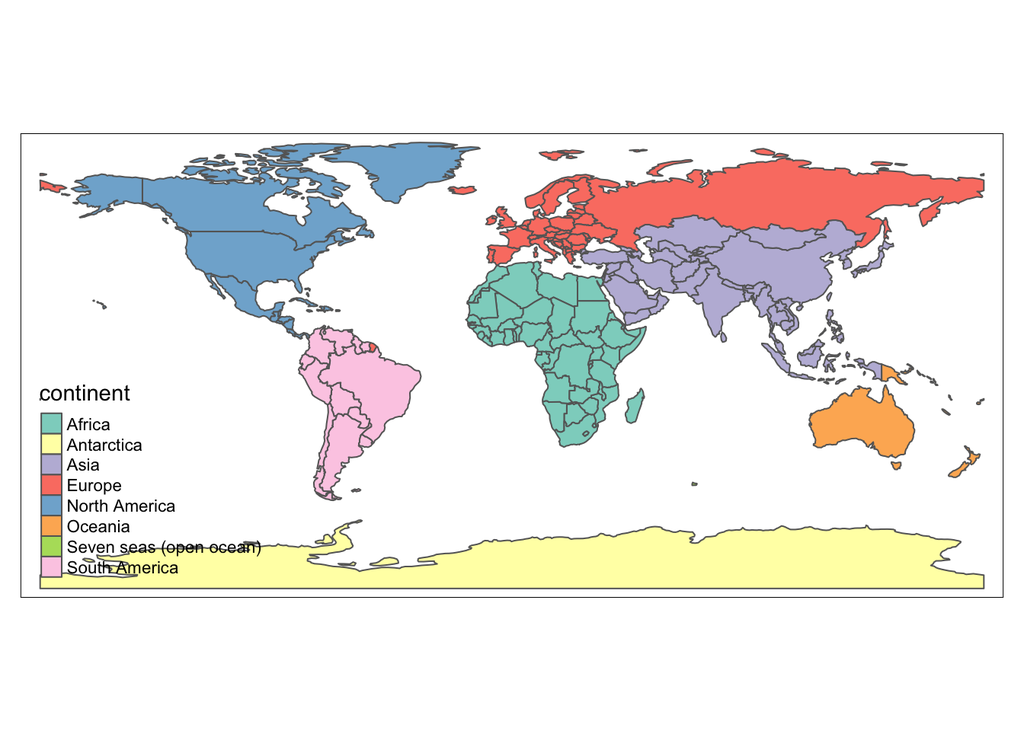

```r
data("World")
tm_shape(World) + tm_polygons("continent") #World is the dataset and "continent" is the variable from the dataset that we want to use to fill polygons
```

Location of Jornada on the world map

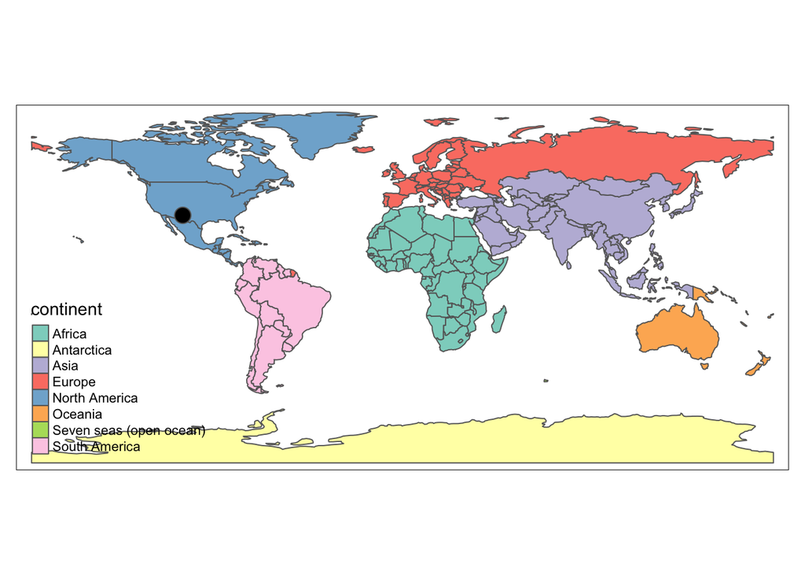

```r
site_sf <- st_as_sf(site, coords = c("Longitude", "Latitude"), crs = st_crs(World))
tm_shape(World) + tm_polygons("continent") + tm_shape(site_sf) + tm_bubbles(size = .5, col = "black")
```

Let’s try plotting the vegetation layer at Jornada

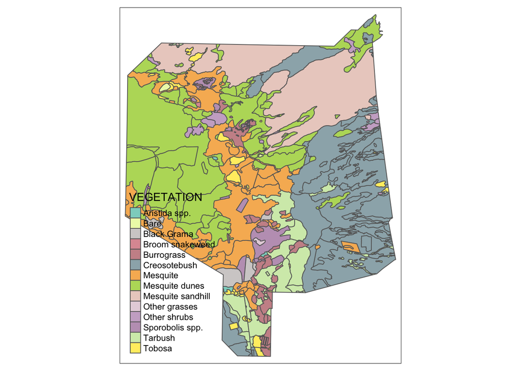

```r
tm_shape(veg) + tm_polygons("VEGETATION")
```

Add the site point to the Jornada vegetation map

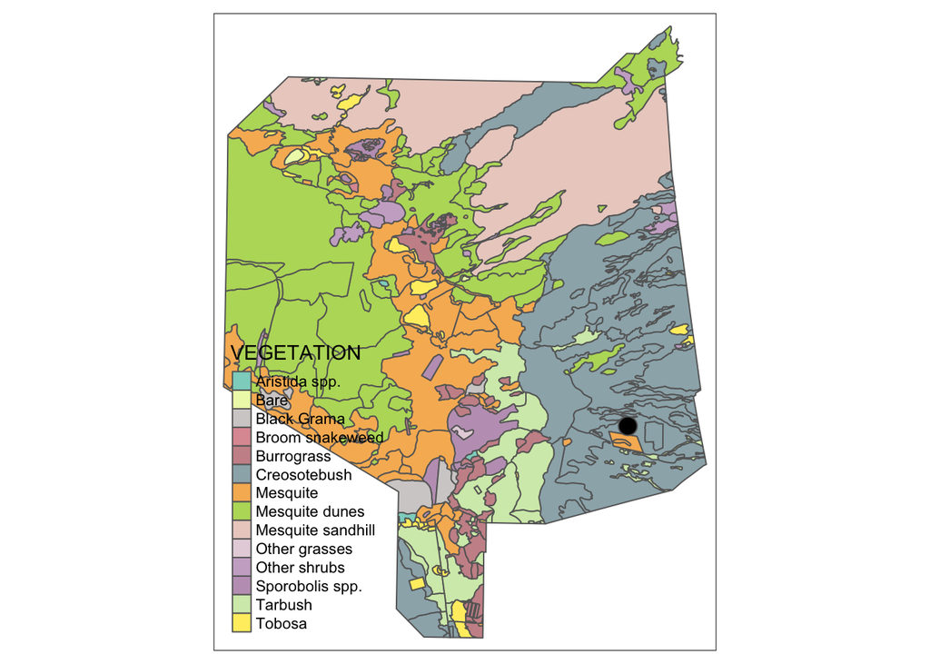

```r
tm_shape(veg) + tm_polygons("VEGETATION") + tm_shape(site_sf) + tm_bubbles(size = .5, col = "black")
```

Saving the map as a pdf

```r
#adding point data and saving a map as a pdf
pdf(file = "fieldsitemap.pdf")
tm_shape(veg) + tm_polygons("VEGETATION") + tm_shape(site_sf) + tm_dots(size = .5, shape = 19, col = "black")
dev.off() #will output to your current working data folder or you can write in the filepath
```

Put the two maps side by side

```r
tmap_mode("plot") #tmap mode set to plotting
```

```
## tmap mode set to plotting
```

```
## Some legend labels were too wide. These labels have been resized to 0.54. Increase legend.width (argument of tm_layout) to make the legend wider and therefore the labels larger.
```

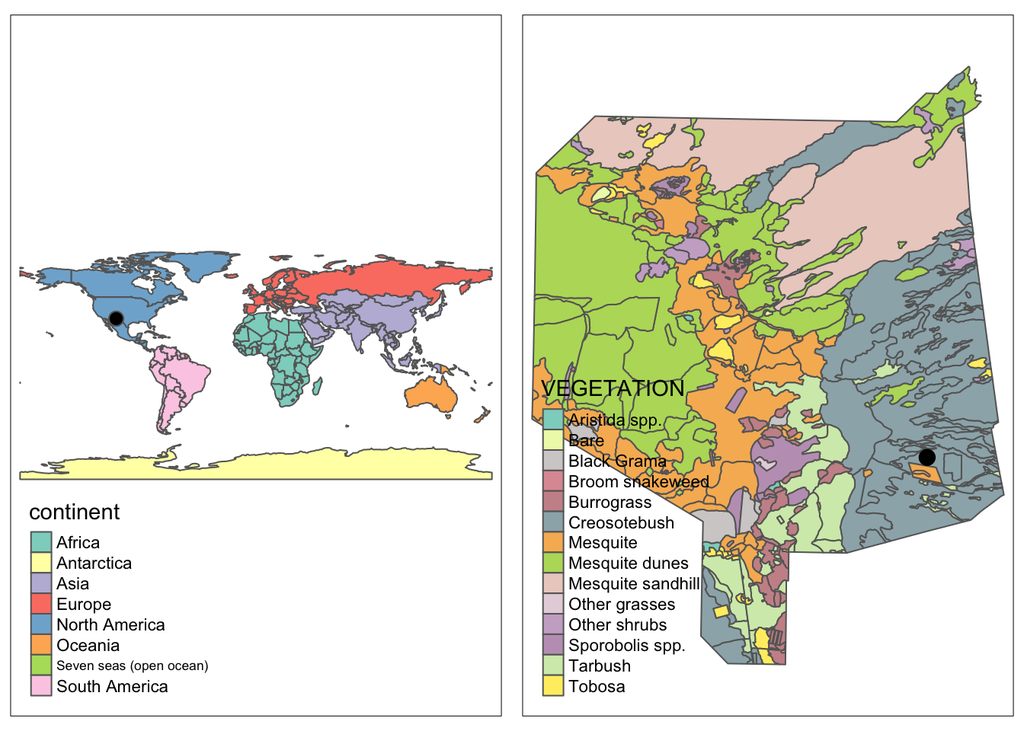

```r
#set each map as a an object
tm1 <- tm_shape(World) + tm_polygons("continent") + tm_shape(site_sf) + tm_bubbles(size = .25, col = "black")
tm2 <- tm_shape(veg) + tm_polygons("VEGETATION") + tm_shape(site_sf) + tm_dots(size = .5, shape = 19, col = "black")
tmap_arrange(tm1, tm2, ncol = 2, nrow = 1)
```

# Example 2

## Map of southwest deserts

```r
#opening the North American Ecoregions level 3 shapefile as an sf spatial object
#source EPA https://www.epa.gov/eco-research/ecoregions-north-america
#10 = deserts
eco3 <- st_read(paste0(wd, "./NA_CEC_Eco_Level3/NA_CEC_Eco_Level3.shp"))
eco3 <- eco3[eco3$NA_L1CODE == "10", ]
#narrow to deserts only, 10.1 = hot, 10.2 = cold deserts
#hot <- eco3[eco3$NA_L2CODE == "10.2", ]
#cold <- eco3[eco3$NA_L2CODE == "10.1", ]
```

Map out the desert shapefile with a shapefile of the USA

```r
World <- World[World$continent == "North America", ] #narrow to NA
eco3 <- st_transform(eco3, crs = st_crs(World)) #match the projection
us <- us_states() #call the us state borders from USAboundaries package
us <- st_transform(us, crs = st_crs(World)) #match the projection

tmap_style("classic") #"watercolor" has pastels
```

```
## tmap style set to "classic"
```

```
## other available styles are: "white", "gray", "natural", "cobalt", "col_blind", "albatross", "beaver", "bw", "watercolor"
```

```r
tm_shape(World) + tm_borders("black", lwd = .5) + tm_shape(us) + tm_borders("black", lwd = .5) + tm_shape(eco3) + tm_polygons("NA_L2NAME", title = "Deserts") + tm_shape(eco3) + tm_borders("black", lwd = .2) + tm_scale_bar() #use "NA_L3NAME" to get desert names
```

```
## Scale bar set for latitude km and will be different at the top and bottom of the map.
```

[figure not shown]